# Student Well-Being

Yosser Akili & Hana Ben Ali

20/04/2022

# Topic

Well-being is considered both the foundation of personal development and its ultimate goal. It refers to a serene and balanced psychological state where an individual can develop in all their potential. In the case of a student, well-being means being in a favorable mental state, free from all the worries and anxieties that hinder progress and skill development.

# Objectives of Principal Component Analysis (PCA)

PCA aims to describe a dataset, summarize it, and reduce its dimensionality. PCA performed on the individuals of the data table addresses various questions: - To what extent can a student’s pocket money meet their needs? - Does the student take medication for stress or pressure? - Does the student engage in sports?

## 1. Presentation of the Dataset:

The dataset {student_wellbeing} is created using an online questionnaire with 591 rows and 48 columns. - The first part represents the timestamp, the well-being score indicating if the individual is flourishing or not, and some personal information: gender and age group. - The second part consists of 13 variables related to the student’s school life, such as attendance in class sessions (class_presence), frequency of attendance (attendance_freq), organization of the schedule (schedule_organization), and supervision. - The third part includes variables describing the student’s health (mental and physical) such as depression, sadness and worry, whether the student has suicidal thoughts or not, back pain, and stomach pain. - The fourth part describes the student’s sports and associative activities.

## 2. Import and Explore the Dataset:

```r
library(FactoMineR)
library(readxl)
data = read_excel("épanouissement_des_étudiants.xlsx")
head(data)
```

```
## # A tibble: 6 × 48
##   Horodateur          Score sexe   age   pres_…¹ pres_…² emplo…³ encad…⁴ forma…⁵
##   <dttm>              <dbl> <chr>  <chr> <chr>     <dbl>   <dbl>   <dbl>   <dbl>
## 1 2022-03-16 14:00:07    25 étudi… 18-23 Oui           1       3       0       1
## 2 2022-03-16 15:09:43    19 étudi… 18-23 Oui           2       1       0       0
## 3 2022-03-16 17:55:09    21 étudi… 18-23 Oui           3       3       3       3
## 4 2022-03-16 18:06:39    23 étudi… 18-23 Oui           2       3       3       1
## 5 2022-03-16 19:01:30    32 étudi… 18-23 Oui           2       2       1       1
## 6 2022-03-16 19:02:02    26 étudi… 18-23 Oui           2       1       2       2
## # … with 39 more variables: trajet <dbl>, interetu <dbl>, interdivert <dbl>,
## #   interinfo <dbl>, argentnecess <dbl>, argentedu <dbl>, argentdiver <dbl>,
## #   argentinvest <dbl>, etat_de_santé <dbl>, maladies_héréditaires <chr>,
## #   maladies_chroniques <chr>, med_antistress <chr>, fumeur <chr>,
## #   `var_poids(6mois)` <chr>, depression <dbl>, mal_détendu <dbl>,
## #   `tristesse/inquietude` <dbl>, temps_insuffisant <dbl>,
## #   troubles_sommeil <dbl>, sensiblilité <dbl>, stress <dbl>, …
```

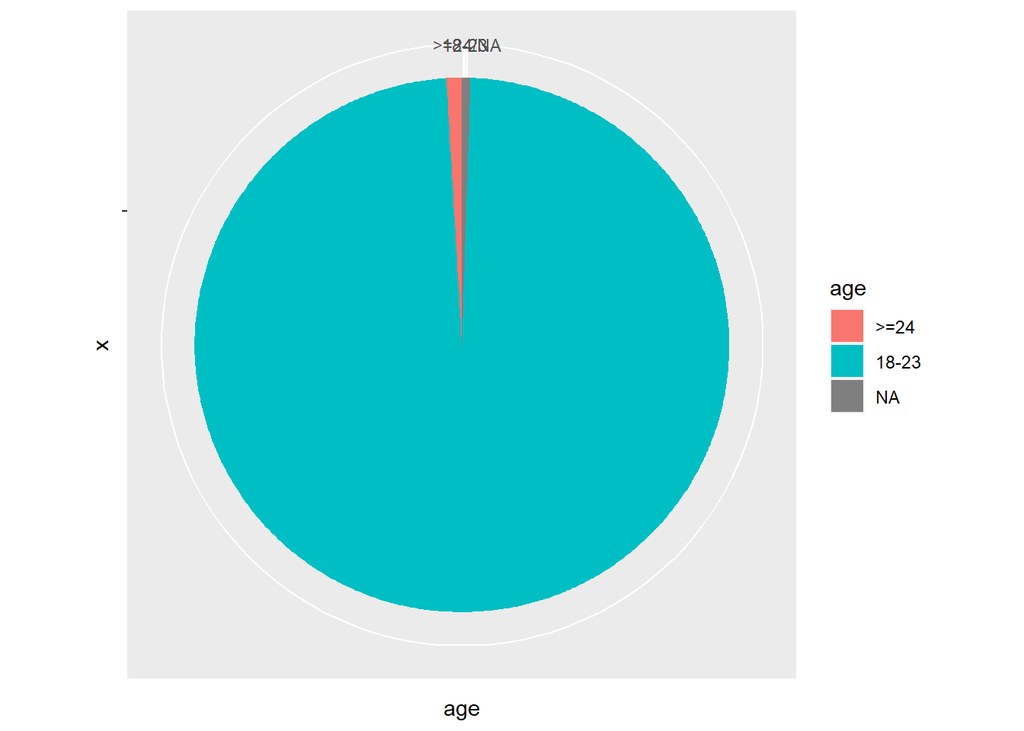

```r
library(ggplot2)
ggplot(data, aes(x="", y=age, fill=age)) +
  geom_bar(stat="identity", width=1) +
  coord_polar("y", start=0)
```

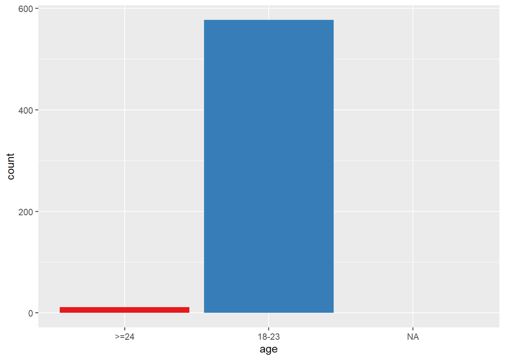

```r
library(ggplot2)
ggplot(data, aes(x=age, fill=age )) +
  geom_bar( ) +
  scale_fill_brewer(palette = "Set1") +
  theme(legend.position="none")
```

## Data Cleaning:

We start by checking for missing values:

```r
sum(is.na(data))
```

```
## [1] 61
```

```r
data <- na.omit(data)
```

# Column Selection

```r
library(dplyr)
data1=select(data,encadrement,formation,interdivert, interetu, argentdiver,sports_collectifs,vie_associative,stress,mauvaise_concentration,etat_memoire,maux_de_tête)

#data1=select(data,argentnecess,argentedu,argentdiver,depression,tristesse.inquietude,stress,mauvaise_concentration,etat_memoire,maux_de_tête)
head(data1)
```

```
## # A tibble: 6 × 11
##   encad…¹ forma…² inter…³ inter…⁴ argen…⁵ sport…⁶ vie_a…⁷ stress mauva…⁸ etat_…⁹
##     <dbl>   <dbl>   <dbl>   <dbl>   <dbl>   <dbl>   <dbl>  <dbl>   <dbl>   <dbl>
## 1       0       1       4       0       1       1       2      1       4       1
## 2       0       0       3       4       3       1       2      4       2       1
## 3       3       3       4       2       2       0       0      4       4       4
## 4       3       1       2       2       2       0       3      2       0       1
## 5       1       1       2       2       3       0       2      2       0       0
## 6       2       2       2       1       2       4       1      1       2       1
## # … with 1 more variable: maux_de_tête <dbl>, and abbreviated variable names
## #   ¹encadrement, ²formation, ³interdivert, ⁴interetu, ⁵argentdiver,
## #   ⁶sports_collectifs, ⁷vie_associative, ⁸mauvaise_concentration,
## #   ⁹etat_memoire
```

```r
#Load the library
library(DataExplorer)
introduce(data1)
```

```
## # A tibble: 1 × 9
##    rows columns discrete_columns conti…¹ all_m…² total…³ compl…⁴ total…⁵ memor…⁶
##   <int>   <int>            <int>   <int>   <int>   <int>   <int>   <int>   <dbl>
## 1   545      11                0      11       0       0     545    5995   51296
## # … with abbreviated variable names ¹continuous_columns, ²all_missing_columns,
## #   ³total_missing_values, ⁴complete_rows, ⁵total_observations, ⁶memory_usage
```

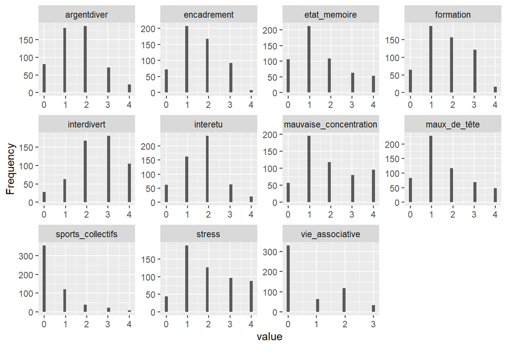

```r
plot_histogram(data1)
```

## Normalized PCA

We start by defining the matrix X composed of the frequencies of variables for each student. We define the weight matrix D=1nIn, where n is the sample size, and the metric M=Ip.

### Calculation of the Centered Reduced Matrix

Center and reduce matrix X.

```r
X=as.matrix(data1)
g=colMeans(X)
g
```

```
##            encadrement              formation            interdivert
##              1.5504587              1.7009174              2.4990826
##               interetu            argentdiver      sports_collectifs
##              1.6660550              1.5853211              0.5522936
##        vie_associative                 stress mauvaise_concentration
##              0.7321101              1.9926606              1.9284404
##           etat_memoire           maux_de_tête
##              1.5321101              1.5798165
```

```r
Y=sweep(x = X,2,g,FUN = '-')
round(colMeans(X),3)
```

```
##            encadrement              formation            interdivert
##                  1.550                  1.701                  2.499
##               interetu            argentdiver      sports_collectifs
##                  1.666                  1.585                  0.552
##        vie_associative                 stress mauvaise_concentration
##                  0.732                  1.993                  1.928
##           etat_memoire           maux_de_tête
##                  1.532                  1.580
```

```r
head(Y)
```

```
##      encadrement  formation interdivert  interetu argentdiver sports_collectifs
## [1,]  -1.5504587 -0.7009174   1.5009174 -1.666055  -0.5853211         0.4477064
## [2,]  -1.5504587 -1.7009174   0.5009174  2.333945   1.4146789         0.4477064
## [3,]   1.4495413  1.2990826   1.5009174  0.333945   0.4146789        -0.5522936
## [4,]   1.4495413 -0.7009174  -0.4990826  0.333945   0.4146789        -0.5522936
## [5,]  -0.5504587 -0.7009174  -0.4990826  0.333945   1.4146789        -0.5522936
## [6,]   0.4495413  0.2990826  -0.4990826 -0.666055   0.4146789         3.4477064
##      vie_associative      stress mauvaise_concentration etat_memoire
## [1,]       1.2678899 -0.99266055             2.07155963   -0.5321101
## [2,]       1.2678899  2.00733945             0.07155963   -0.5321101
## [3,]      -0.7321101  2.00733945             2.07155963    2.4678899
## [4,]       2.2678899  0.00733945            -1.92844037   -0.5321101
## [5,]       1.2678899  0.00733945            -1.92844037   -1.5321101
## [6,]       0.2678899 -0.99266055             0.07155963   -0.5321101
##      maux_de_tête
## [1,]   -1.5798165
## [2,]   -0.5798165
## [3,]    2.4201835
## [4,]    0.4201835
## [5,]   -0.5798165
## [6,]   -1.5798165
```

```r
n=nrow(X)
p=ncol(X)
et=apply(Y,2,function(x) sqrt(sum(x^2)/n))
et
```

```
##            encadrement              formation            interdivert
##              0.9624723              1.0318324              1.0838680
##               interetu            argentdiver      sports_collectifs
##              0.9551618              1.0247242              0.9154731
##        vie_associative                 stress mauvaise_concentration
##              0.9962204              1.2220982              1.2708512
##           etat_memoire           maux_de_tête
##              1.2113288              1.1531990
```

Calculation of the matrix of reduced input data Z. Verify that the variables in this matrix have a variance equal to 1.

```r
Z=sweep(x = Y,2,et,FUN = '/')
colSums(Z^2)/n
```

```
##            encadrement              formation            interdivert
##                      1                      1                      1
##               interetu            argentdiver      sports_collectifs
##                      1                      1                      1
##        vie_associative                 stress mauvaise_concentration
##                      1                      1                      1
##           etat_memoire           maux_de_tête
##                      1                      1
```

### 2. Calculation of the Correlation Matrix

Calculation of the correlation matrix R=Z′DZ, its eigenvalues, and eigenvectors.

```r
M=diag(rep(1,p))
D=(1/n)*diag(rep(1,n))
R=t(Z)%*%D%*%Z
vp=eigen(R %*%M)
lambda=vp$values
lambda
```

```
##  [1] 2.4290701 1.4338379 1.2603487 1.1456046 0.9703641 0.8418023 0.7759762
##  [8] 0.5992740 0.5871522 0.5169043 0.4396656
```

```r
U=vp$vectors
U
```

```
##              [,1]        [,2]        [,3]        [,4]        [,5]         [,6]
##  [1,] -0.21046028 -0.62120006 -0.08825800  0.19557141 -0.02704779  0.148915192
##  [2,] -0.18591067 -0.64277645 -0.01076000  0.20383049  0.08220250  0.105631463
##  [3,]  0.04493560 -0.08380343  0.68232874 -0.15652815 -0.11980689  0.234651533
##  [4,]  0.03013218 -0.03541270 -0.61427773 -0.32263316 -0.25698941  0.271873236
##  [5,] -0.13812553 -0.11215611  0.14449239 -0.49387728 -0.66195297  0.098236869
##  [6,] -0.20592891 -0.24264898  0.02058683 -0.44153570  0.12981074 -0.795409196
##  [7,] -0.12707392 -0.03394906  0.05934554 -0.55929226  0.63304957  0.431343716
##  [8,]  0.46125784 -0.20207012 -0.10730868 -0.05530864 -0.13701727  0.008891296
##  [9,]  0.46514504 -0.18659368  0.26856962  0.01730876 -0.04097252 -0.058804850
## [10,]  0.46824220 -0.15287960  0.02435673 -0.09358046  0.12272299 -0.015672584
## [11,]  0.43842207 -0.14505199 -0.20030801 -0.16679156  0.14427814 -0.074320200
##                [,7]         [,8]        [,9]       [,10]       [,11]
##  [1,]  0.0496603830 -0.279074218 -0.06758241  0.64308581  0.04895580
##  [2,] -0.0004268987  0.229170971  0.12022876 -0.65174789 -0.03078911
##  [3,] -0.5619784746 -0.085652881  0.29112283  0.06309835 -0.13992513
##  [4,] -0.5471454026 -0.186836217 -0.10220238 -0.14204837  0.10747635
##  [5,]  0.4984848530  0.022006606  0.03490146 -0.06245410  0.04033908
##  [6,] -0.2126097419 -0.015579582 -0.07291376  0.03046548 -0.04604733
##  [7,]  0.1517328676  0.143012787 -0.17605752  0.05943416  0.03945389
##  [8,] -0.0708251313  0.627262601 -0.19926656  0.24216115 -0.46492810
##  [9,] -0.0477567116  0.006645448 -0.46842379 -0.07787757  0.66591762
## [10,]  0.2075285848 -0.640925448 -0.12152837 -0.22562876 -0.46172386
## [11,]  0.1235630863  0.043432984  0.75786008  0.11631780  0.29568160
```

Verify that the eigenvectors (i.e., the columns of U) are indeed orthonormal.

```r
round(t(U)%*%U,3)
```

```
##       [,1] [,2] [,3] [,4] [,5] [,6] [,7] [,8] [,9] [,10] [,11]
##  [1,]    1    0    0    0    0    0    0    0    0     0     0
##  [2,]    0    1    0    0    0    0    0    0    0     0     0
##  [3,]    0    0    1    0    0    0    0    0    0     0     0
##  [4,]    0    0    0    1    0    0    0    0    0     0     0
##  [5,]    0    0    0    0    1    0    0    0    0     0     0
##  [6,]    0    0    0    0    0    1    0    0    0     0     0
##  [7,]    0    0    0    0    0    0    1    0    0     0     0
##  [8,]    0    0    0    0    0    0    0    1    0     0     0
##  [9,]    0    0    0    0    0    0    0    0    1     0     0
## [10,]    0    0    0    0    0    0    0    0    0     1     0
## [11,]    0    0    0    0    0    0    0    0    0     0     1
```

### 3. Principal Components

Calculate the matrix Psi of principal components given by Psi=Zu. Verify that the variance of each component is equal to the corresponding eigenvalue.

```r
Psi=Z%*%U
head(Psi)
```

```
##            [,1]       [,2]       [,3]        [,4]       [,5]       [,6]
## [1,] -0.1312994  1.4110880  2.9575430 -0.41040607  1.3102993 -0.3514323
## [2,]  0.6444692  1.4159817 -0.8117828 -3.08621342 -1.1737647  0.7099003
## [3,]  3.0733732 -2.9992544  0.4768493  0.09581275 -0.7434282  0.7107293
## [4,] -1.1707818 -0.1527713 -0.9652801 -1.13761597  1.0236986  1.7101815
## [5,] -1.5074175  1.3146894 -0.5468559 -1.24266862 -0.4279534  1.1410102
## [6,] -2.2142636 -0.9620183  0.5877775 -1.25011256  0.4942171 -2.9390906
##            [,7]        [,8]       [,9]       [,10]       [,11]
## [1,] -0.3799117  0.38637078 -1.2575961 -0.51574232  0.82635490
## [2,] -1.1709658  1.07082428 -1.0973901  0.15880322 -0.41877831
## [3,] -0.1888280 -0.57599999  0.8565316  0.15359879 -0.10444106
## [4,]  0.8438680  0.03306623  0.3432096  1.68530971 -0.37214919
## [5,]  0.7963525  0.98234398  0.1375752  0.31378238 -0.34934610
## [6,] -0.1003900 -0.19258808 -1.2166759  0.02557671  0.06984102
```

```r
round(t(Psi)%*%D%*%Psi,3)
```

```
##        [,1]  [,2] [,3]  [,4] [,5]  [,6]  [,7]  [,8]  [,9] [,10] [,11]
##  [1,] 2.429 0.000 0.00 0.000 0.00 0.000 0.000 0.000 0.000 0.000  0.00
##  [2,] 0.000 1.434 0.00 0.000 0.00 0.000 0.000 0.000 0.000 0.000  0.00
##  [3,] 0.000 0.000 1.26 0.000 0.00 0.000 0.000 0.000 0.000 0.000  0.00
##  [4,] 0.000 0.000 0.00 1.146 0.00 0.000 0.000 0.000 0.000 0.000  0.00
##  [5,] 0.000 0.000 0.00 0.000 0.97 0.000 0.000 0.000 0.000 0.000  0.00
##  [6,] 0.000 0.000 0.00 0.000 0.00 0.842 0.000 0.000 0.000 0.000  0.00
##  [7,] 0.000 0.000 0.00 0.000 0.00 0.000 0.776 0.000 0.000 0.000  0.00
##  [8,] 0.000 0.000 0.00 0.000 0.00 0.000 0.000 0.599 0.000 0.000  0.00
##  [9,] 0.000 0.000 0.00 0.000 0.00 0.000 0.000 0.000 0.587 0.000  0.00
## [10,] 0.000 0.000 0.00 0.000 0.00 0.000 0.000 0.000 0.000 0.517  0.00
## [11,] 0.000 0.000 0.00 0.000 0.00 0.000 0.000 0.000 0.000 0.000  0.44
```

### 4. Coordinates of Variables on the Axes

```r
Eta<-sweep(U,2,sqrt(lambda),FUN='*')
Eta
```

```
##              [,1]        [,2]        [,3]        [,4]        [,5]         [,6]
##  [1,] -0.32801233 -0.74384341 -0.09908306  0.20932579 -0.02664398  0.136629364
##  [2,] -0.28975060 -0.76967962 -0.01207974  0.21816573  0.08097527  0.096916638
##  [3,]  0.07003427 -0.10034872  0.76601808 -0.16753665 -0.11801825  0.215292271
##  [4,]  0.04696243 -0.04240422 -0.68962043 -0.34532370 -0.25315272  0.249443103
##  [5,] -0.21527519 -0.13429906  0.16221474 -0.52861128 -0.65207043  0.090132113
##  [6,] -0.32094998 -0.29055510  0.02311186 -0.47258856  0.12787274 -0.729786206
##  [7,] -0.19805073 -0.04065161  0.06662442 -0.59862684  0.62359854  0.395756921
##  [8,]  0.71889222 -0.24196476 -0.12047036 -0.05919846 -0.13497169  0.008157745
##  [9,]  0.72495061 -0.22343281  0.30151036  0.01852607 -0.04036083 -0.053953322
## [10,]  0.72977769 -0.18306257  0.02734414 -0.10016190  0.12089081 -0.014379562
## [11,]  0.68330160 -0.17368957 -0.22487629 -0.17852188  0.14212416 -0.068188621
##               [,7]         [,8]        [,9]       [,10]       [,11]
##  [1,]  0.043745590 -0.216039129 -0.05178560  0.46235333  0.03246126
##  [2,] -0.000376053  0.177407635  0.09212632 -0.46858102 -0.02041542
##  [3,] -0.495044106 -0.066306282  0.22307536  0.04536523 -0.09278055
##  [4,] -0.481977725 -0.144635122 -0.07831345 -0.10212717  0.07126465
##  [5,]  0.439112883  0.017035927  0.02674355 -0.04490203  0.02674775
##  [6,] -0.187286888 -0.012060589 -0.05587079  0.02190348 -0.03053274
##  [7,]  0.133660745  0.110710184 -0.13490558  0.04273081  0.02616081
##  [8,] -0.062389514  0.485581459 -0.15268971  0.17410431 -0.30828119
##  [9,] -0.042068655  0.005144427 -0.35893374 -0.05599090  0.44155188
## [10,]  0.182810921 -0.496158250 -0.09312215 -0.16221818 -0.30615655
## [11,]  0.108846122  0.033622683  0.58071679  0.08362791  0.19605844
```

```r
round(t(U)%*%U,3)
```

```
##       [,1] [,2] [,3] [,4] [,5] [,6] [,7] [,8] [,9] [,10] [,11]
##  [1,]    1    0    0    0    0    0    0    0    0     0     0
##  [2,]    0    1    0    0    0    0    0    0    0     0     0
##  [3,]    0    0    1    0    0    0    0    0    0     0     0
##  [4,]    0    0    0    1    0    0    0    0    0     0     0
##  [5,]    0    0    0    0    1    0    0    0    0     0     0
##  [6,]    0    0    0    0    0    1    0    0    0     0     0
##  [7,]    0    0    0    0    0    0    1    0    0     0     0
##  [8,]    0    0    0    0    0    0    0    1    0     0     0
##  [9,]    0    0    0    0    0    0    0    0    1     0     0
## [10,]    0    0    0    0    0    0    0    0    0     1     0
## [11,]    0    0    0    0    0    0    0    0    0     0     1
```

# Standardized PCA with the FactoMineR Package and PCA Interpretation

Now, let’s use the PCA function to obtain the results obtained previously.

Note that we are using the factoextra package rather than FactoMineR for the quality of its graphics.

### 1. Relevance of PCA

The corrgram below allows us to study the correlations between quantitative variables:

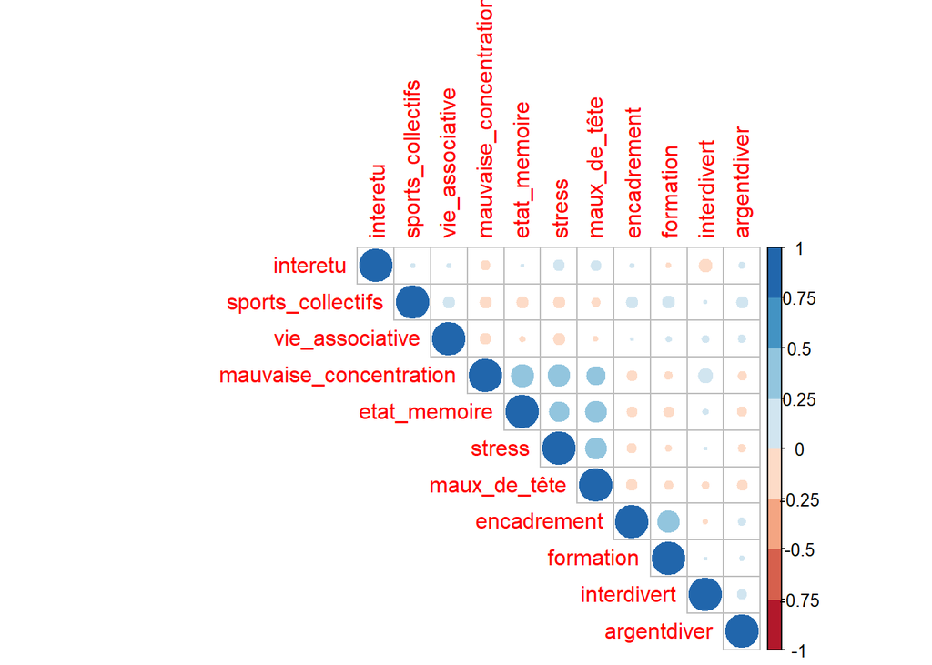

```r
library(corrplot)
X=as.matrix(data1)
M<-cor(X)
library(RColorBrewer)
corrplot(M, type="upper", order="hclust",
         col=brewer.pal(n=8, name="RdBu"))
```

The correlation matrix shows that the variables encadrement and formation are strongly and positively correlated, as well as etat_memoire, mauvaise_concentration, stress, and maux_de_tête.

While the modalities sports_collectifs and stress are negatively correlated, as well as sports_collectifs and etat_memoire, sports_collectifs, and maux_de_tête.

The modality interdivert (internet usage for entertainment) and etat_memoire are positively correlated.

## 2. Choosing the Number of Retained Axes

Three criteria should be used: cumulative inertia rate, Kaiser criterion, and the elbow criterion.

The eig object is a matrix with three columns containing the eigenvalues of PCA, the proportion of variance of each component, and the cumulative variance by the principal components.

```r
library(factoextra)
```

```r
res.pca=PCA(data1,ncp = 5,scale.unit=TRUE,graph = F)
head(res.pca$eig)
```

```
##        eigenvalue percentage of variance cumulative percentage of variance
## comp 1  2.4290701              22.082456                          22.08246
## comp 2  1.4338379              13.034890                          35.11735
## comp 3  1.2603487              11.457715                          46.57506
## comp 4  1.1456046              10.414588                          56.98965
## comp 5  0.9703641               8.821492                          65.81114
## comp 6  0.8418023               7.652748                          73.46389
```

Considering the observations, it would probably be necessary to also consider dimensions greater than or equal to the third in the analysis.

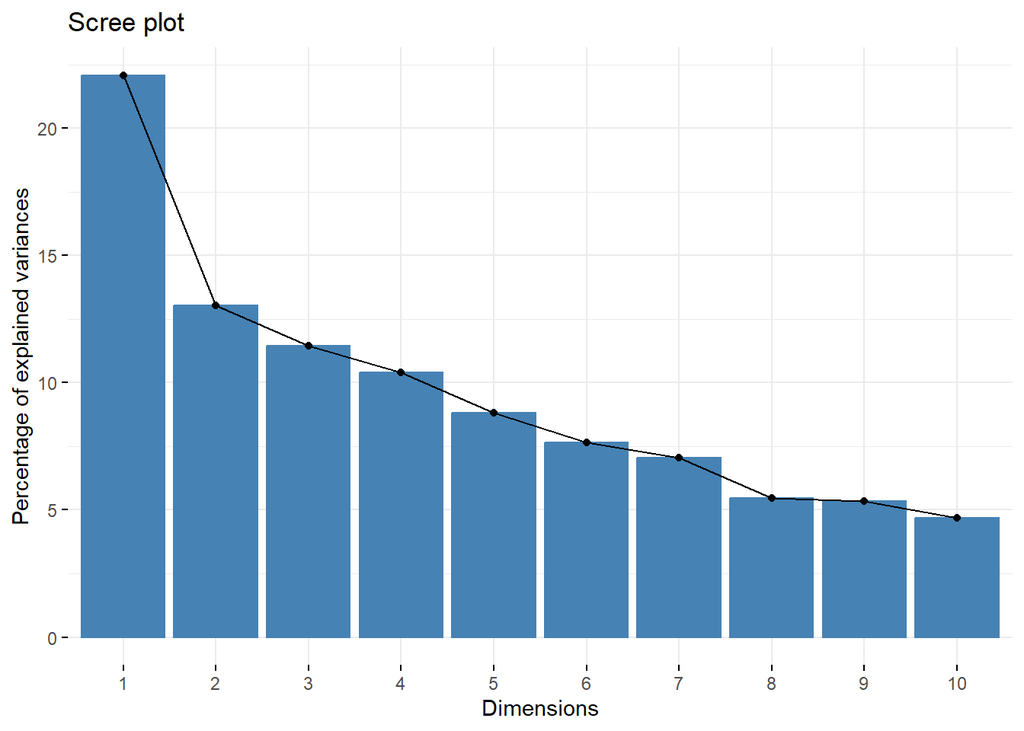

```r
fviz_screeplot(res.pca, ncp=10)
```

**Figure 2 - Decomposition of Total Inertia**

```r
names(res.pca$var)
```

```
## [1] "coord"   "cor"     "cos2"    "contrib"
```

The coord object in var contains the coordinates of the variables.

```r
res.pca$var$coord
```

```
##                              Dim.1      Dim.2       Dim.3       Dim.4
## encadrement            -0.32801233 0.74384341 -0.09908306 -0.20932579
## formation              -0.28975060 0.76967962 -0.01207974 -0.21816573
## interdivert             0.07003427 0.10034872  0.76601808  0.16753665
## interetu                0.04696243 0.04240422 -0.68962043  0.34532370
## argentdiver            -0.21527519 0.13429906  0.16221474  0.52861128
## sports_collectifs      -0.32094998 0.29055510  0.02311186  0.47258856
## vie_associative        -0.19805073 0.04065161  0.06662442  0.59862684
## stress                  0.71889222 0.24196476 -0.12047036  0.05919846
## mauvaise_concentration  0.72495061 0.22343281  0.30151036 -0.01852607
## etat_memoire            0.72977769 0.18306257  0.02734414  0.10016190
## maux_de_tête            0.68330160 0.17368957 -0.22487629  0.17852188
##                              Dim.5
## encadrement             0.02664398
## formation              -0.08097527
## interdivert             0.11801825
## interetu                0.25315272
## argentdiver             0.65207043
## sports_collectifs      -0.12787274
## vie_associative        -0.62359854
## stress                  0.13497169
## mauvaise_concentration  0.04036083
## etat_memoire           -0.12089081
## maux_de_tête           -0.14212416
```

The cos2 object in var is a matrix whose rows represent the squared cosine of the variable (i.e., the square of the coordinates since the PCA is standardized).

```r
res.pca$var$cos2
```

```
##                              Dim.1       Dim.2        Dim.3        Dim.4
## encadrement            0.107592086 0.553303023 0.0098174531 0.0438172874
## formation              0.083955412 0.592406724 0.0001459201 0.0475962840
## interdivert            0.004904799 0.010069865 0.5867836961 0.0280685290
## interetu               0.002205470 0.001798118 0.4755763414 0.1192484582
## argentdiver            0.046343409 0.018036238 0.0263136221 0.2794298886
## sports_collectifs      0.103008887 0.084422267 0.0005341580 0.2233399507
## vie_associative        0.039224092 0.001652554 0.0044388134 0.3583540986
## stress                 0.516806025 0.058546947 0.0145131078 0.0035044572
## mauvaise_concentration 0.525553393 0.049922222 0.0909084984 0.0003432153
## etat_memoire           0.532575477 0.033511905 0.0007477022 0.0100324068
## maux_de_tête           0.466901074 0.030168065 0.0505693469 0.0318700602
##                               Dim.5
## encadrement            0.0007099018
## formation              0.0065569947
## interdivert            0.0139283064
## interetu               0.0640862992
## argentdiver            0.4251958459
## sports_collectifs      0.0163514386
## vie_associative        0.3888751361
## stress                 0.0182173577
## mauvaise_concentration 0.0016289963
## etat_memoire           0.0146145889
## maux_de_tête           0.0201992770
```

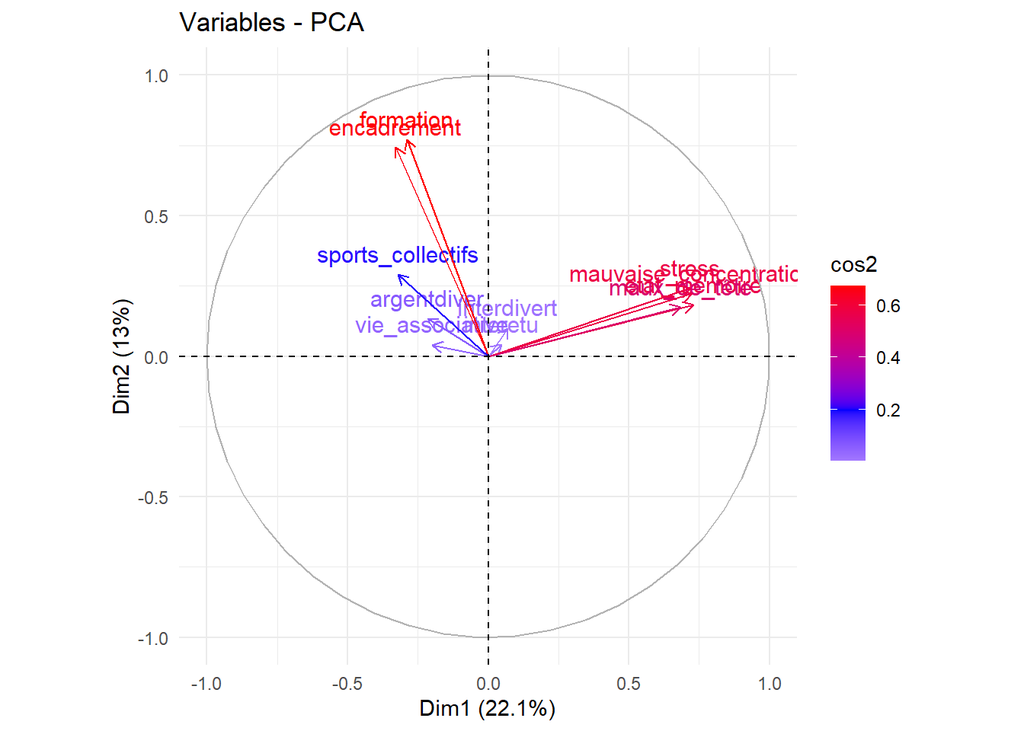

```r
fviz_pca_var(res.pca, col.var="cos2") +
  scale_color_gradient2(low="white", mid="blue",
                        high="RED", midpoint=0.2) +
  theme_minimal()
```

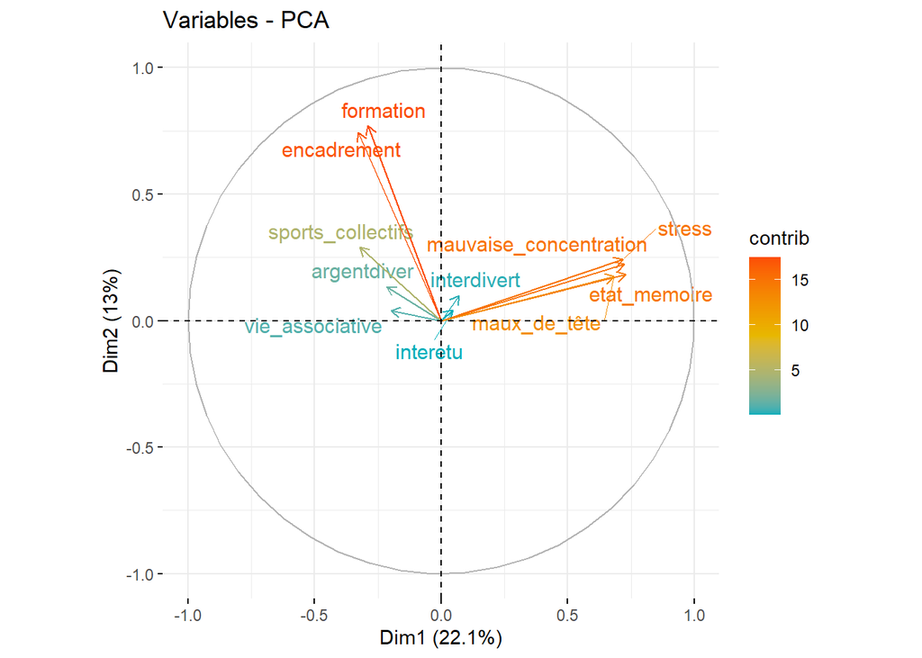

```r
fviz_pca_var(res.pca, col.var = "contrib", gradient.cols = c("#00AFBB", "#E7B800", "#FC4E07"),repel = TRUE)
```

**Figure 3.2 - Variable Graph (PCA)** *The labeled variables are the ones best represented on the plot.*

The **dimension 1** opposes individuals characterized by a strongly positive coordinate on the axis (right side of the plot) to individuals characterized by a strongly negative coordinate on the axis (left side of the plot).

Group 1 (characterized by a positive coordinate on the axis) shares:

- High values for the variables *stress*, *mauvaise_concentration*, *etat_memoire*, *maux_de_tête* & *interdivert* (from most extreme to least extreme).
- Low values for the variables *sports_collectifs*, *argentdiver* & *vie_associative* (from most extreme to least extreme).

The **dimension 2** opposes individuals characterized by a strongly positive coordinate on the axis (top of the plot) to individuals characterized by a strongly negative coordinate on the axis (bottom of the plot).

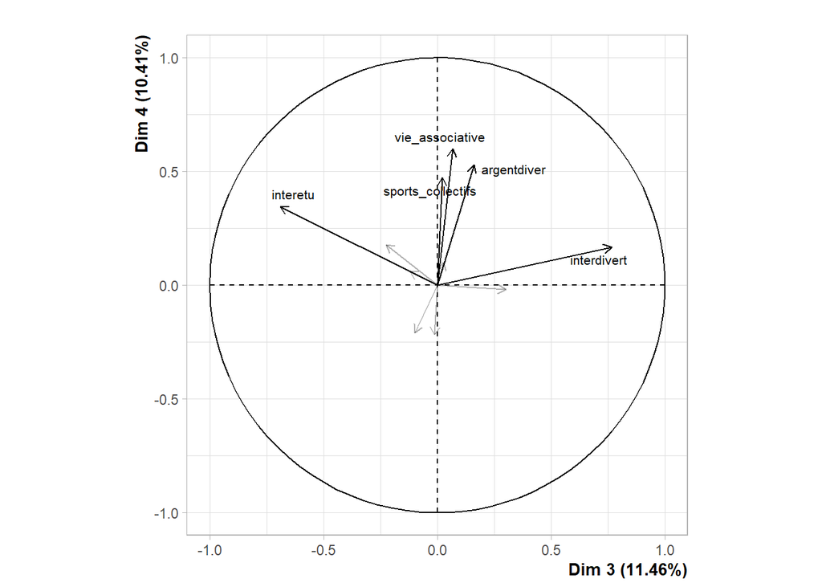

```r
drawn <-
c("interdivert", "interetu", "argentdiver", "vie_associative",
"sports_collectifs")
par(mar = c(4.1, 4.1, 1.1, 2.1))
plot.PCA(res.pca, select = drawn, axes = 3:4, choix = 'var', title = '', cex = 0.7)
```

**Figure 4.2 - Graph of Variables (PCA)** *The labeled variables are those best represented on the plane.*

The **dimension 3** contrasts individuals characterized by a strongly positive coordinate on the axis (right side of the graph) with individuals characterized by a strongly negative coordinate on the axis (left side of the graph).

Group 2 (characterized by negative coordinates on the axis) shares:

- High values for the variables *interetu*, *maux_de_tête* & *stress* (from most extreme to least extreme).
- Low values for the variables *interdivert*, *argentdiver*, *mauvaise_concentration* & *sports_collectifs* (from most extreme to least extreme).

**Dimension 4** contrasts individuals characterized by a strongly positive coordinate on the axis (top of the graph) with individuals characterized by a strongly negative coordinate on the axis (bottom of the graph).

Group 1 (characterized by a positive coordinate on the axis) shares:

- High values for the variables *argentdiver*, *sports_collectifs*, *vie_associative*, *interdivert* et *interetu* (from most extreme to least extreme).
- Low values for the variables *formation* & *encadrement* (from most extreme to least extreme).

# Individual Graph:

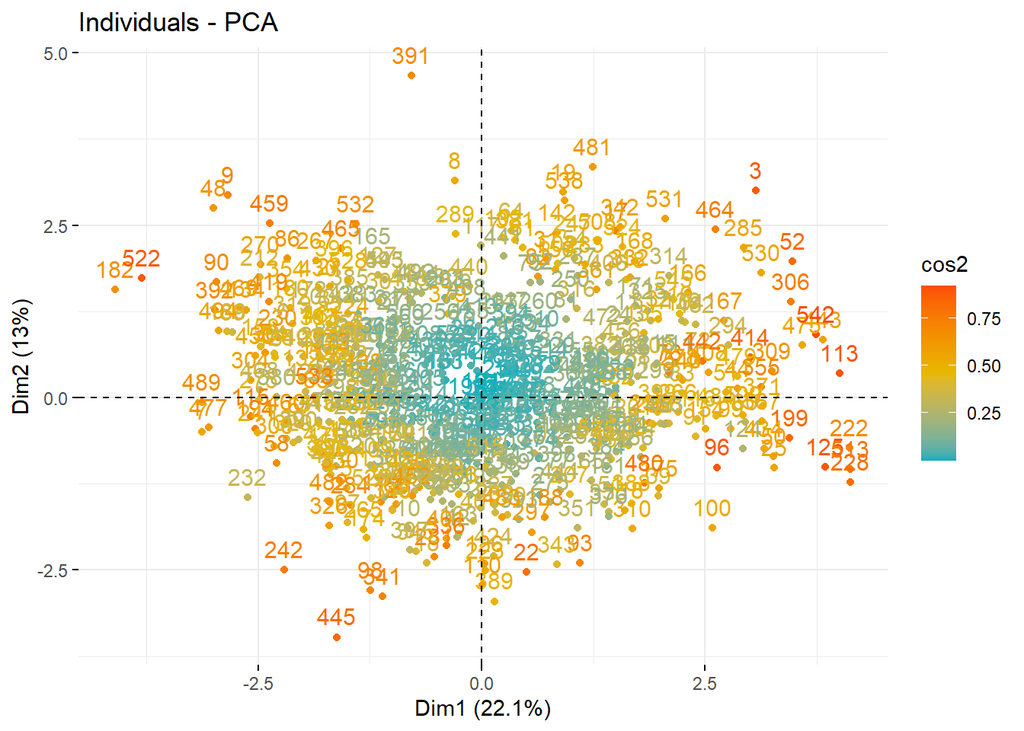

```r
fviz_pca_ind(res.pca, col.ind = "cos2",
             gradient.cols = c("#00AFBB", "#E7B800", "#FC4E07"),

)
```

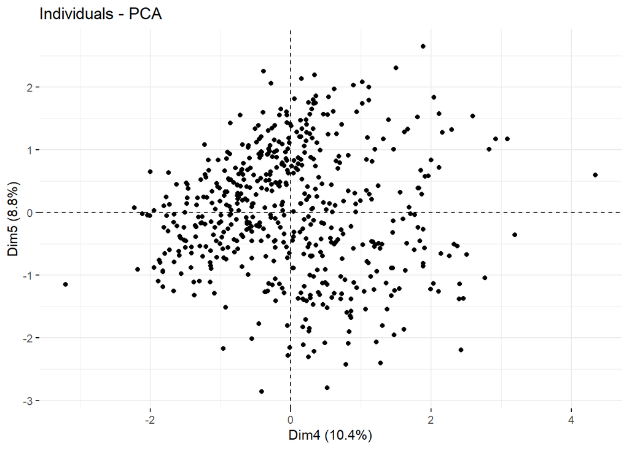

```r
fviz_pca_ind(res.pca,axes=c(4, 5),geom = "point",col.ind.sup = 'gray')
```

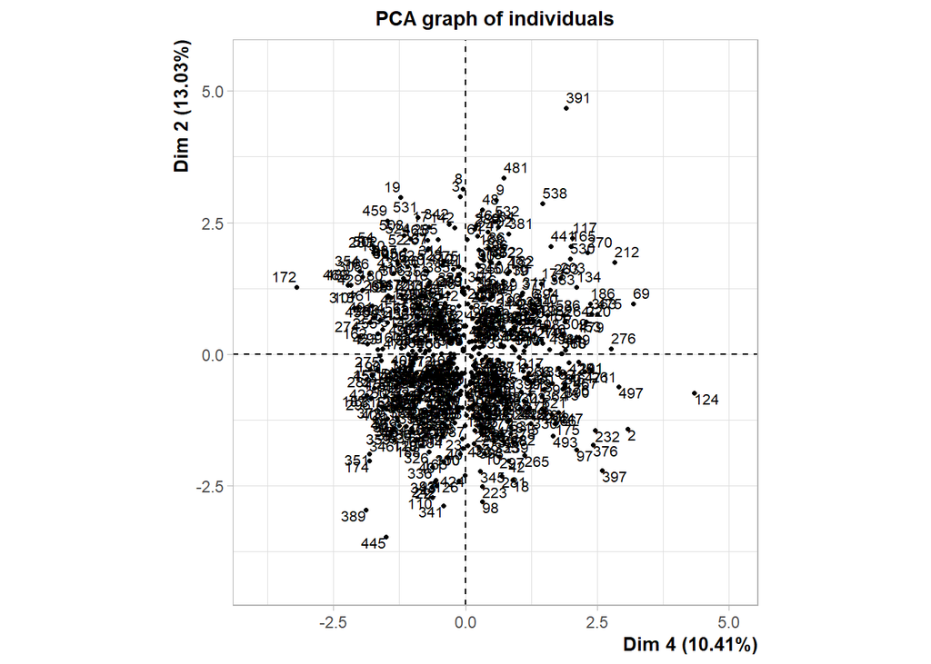

```r
plot.PCA(res.pca, axes=c(4, 2), choix="ind", cex=0.7)
```

CLustering using HCPC

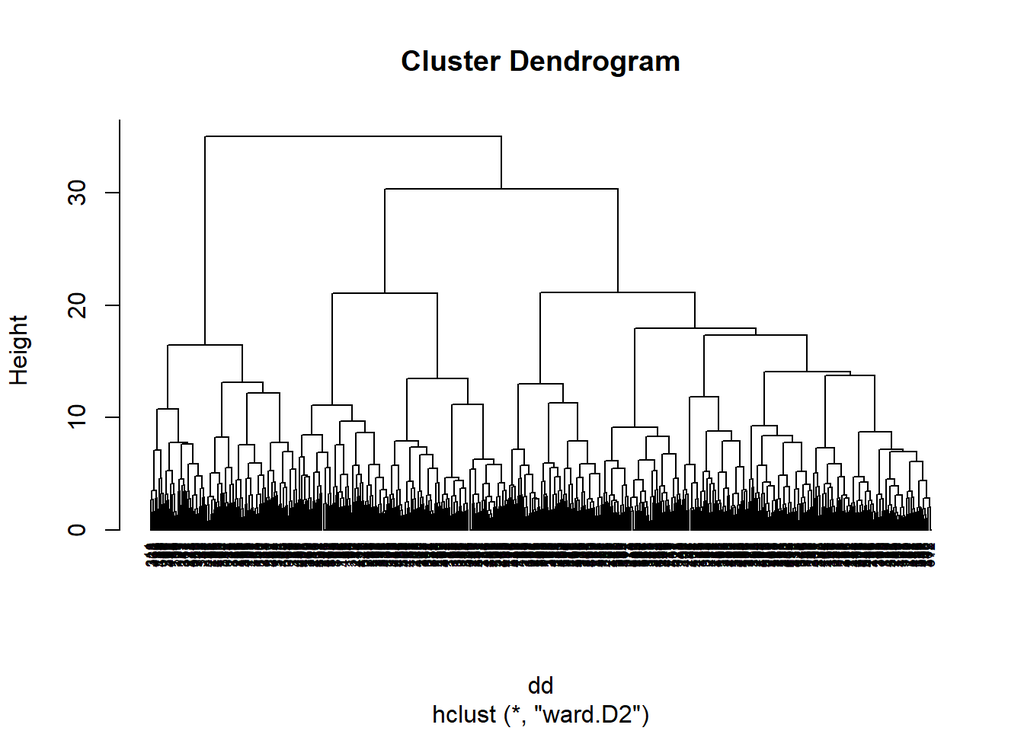

```r
dd <- dist(scale(data1), method = "euclidean")
hc <- hclust(dd, method = "ward.D2")
plot(hc, hang = -1, cex = 0.6)
```

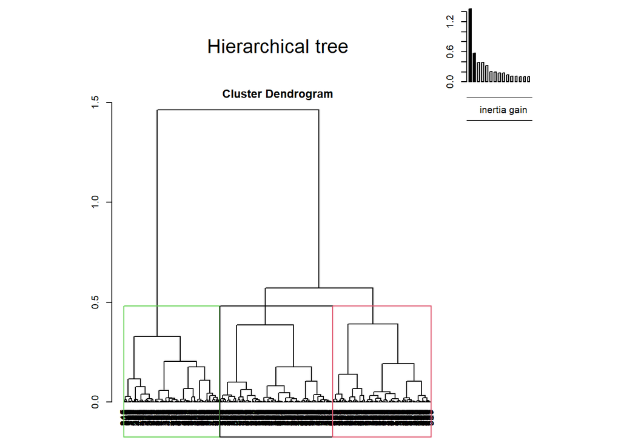

```r
library(FactoMineR)
res.HCPC<-HCPC(res.pca,consol=TRUE,graph=FALSE)
plot.HCPC(res.HCPC,choice='tree',title='Hierarchical tree')
```

- Hierarchical tree: The classification on individuals reveals 3 classes. They can be projected onto the dimension 1 and 2 map or visualize the Hierarchical tree on the 3D plane.

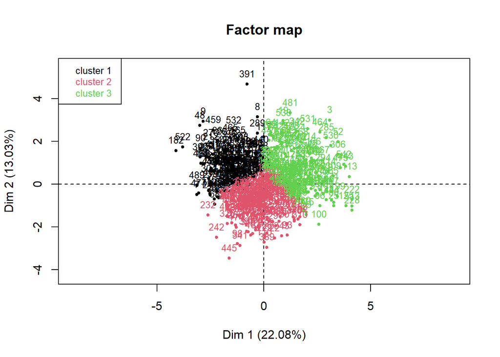

```r
plot.HCPC(res.HCPC,choice='map',draw.tree=FALSE,title='Factor map')
```

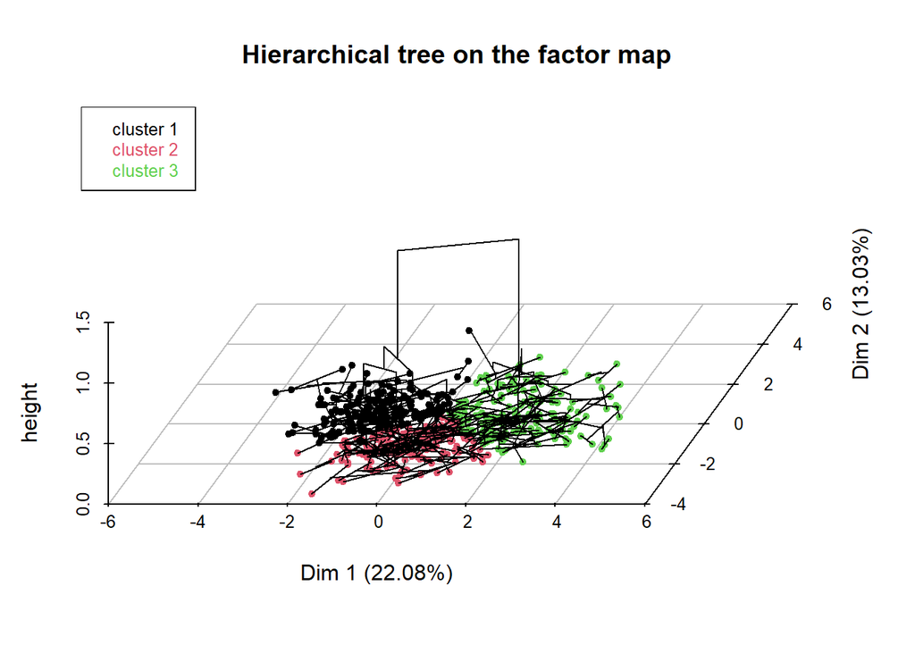

```r
plot.HCPC(res.HCPC,choice='3D.map',ind.names=FALSE,centers.plot=FALSE,angle=60,title='Hierarchical tree on the factor map')
```

Class Descriptions:

```r
head(res.HCPC$data.clust) # cette commande nous  montre a quelle classe appartient chaque individu
```

```
##   encadrement formation interdivert interetu argentdiver sports_collectifs
## 1           0         1           4        0           1                 1
## 2           0         0           3        4           3                 1
## 3           3         3           4        2           2                 0
## 4           3         1           2        2           2                 0
## 5           1         1           2        2           3                 0
## 6           2         2           2        1           2                 4
##   vie_associative stress mauvaise_concentration etat_memoire maux_de_tête clust
## 1               2      1                      4            1            0     2
## 2               2      4                      2            1            1     2
## 3               0      4                      4            4            4     3
## 4               3      2                      0            1            2     1
## 5               2      2                      0            0            1     2
## 6               1      1                      2            1            0     1
```

**Note:** Describing classes by individuals in our case is not useful since visualizing the most characteristic individual in class; in other words, the furthest from other classes, doesn’t provide much information, especially since individuals don’t have names, they are labeled by numbers.

# Description of classes by variables / Factorial axes

```r
res.HCPC$desc.var  # Description des classe par les variables
```

```
##
## Link between the cluster variable and the quantitative variables
## ================================================================
##                              Eta2      P-value
## stress                 0.40513558 7.366768e-62
## etat_memoire           0.39153170 3.376656e-59
## mauvaise_concentration 0.36910635 6.139303e-55
## maux_de_tête           0.34994984 2.035171e-51
## formation              0.32407738 7.981458e-47
## encadrement            0.31811322 8.630276e-46
## sports_collectifs      0.15197637 3.967848e-20
## argentdiver            0.03757649 3.106321e-05
## vie_associative        0.02731109 5.507369e-04
##
## Description of each cluster by quantitative variables
## =====================================================
## $`1`
##                           v.test Mean in category Overall mean sd in category
## encadrement            12.037738        2.2882353    1.5504587      0.7230510
## formation              11.176814        2.4352941    1.7009174      0.8252922
## sports_collectifs       9.092581        1.0823529    0.5522936      1.1902720
## argentdiver             4.371727        1.8705882    1.5853211      1.0265675
## vie_associative         2.646534        0.9000000    0.7321101      1.0154686
## etat_memoire           -8.499851        0.8764706    1.5321101      0.7452038
## maux_de_tête           -8.616710        0.9470588    1.5798165      0.7612819
## mauvaise_concentration -8.710595        1.2235294    1.9284404      0.9564207
## stress                 -9.203020        1.2764706    1.9926606      0.9203768
##                        Overall sd      p.value
## encadrement             0.9624723 2.250421e-33
## formation               1.0318324 5.295744e-29
## sports_collectifs       0.9154731 9.671532e-20
## argentdiver             1.0247242 1.232677e-05
## vie_associative         0.9962204 8.132142e-03
## etat_memoire            1.2113288 1.898336e-17
## maux_de_tête            1.1531990 6.890551e-18
## mauvaise_concentration  1.2708512 3.022827e-18
## stress                  1.2220982 3.480266e-20
##
## $`2`
##                            v.test Mean in category Overall mean sd in category
```

[output cut: 18 more lines]

```
## stress                 14.633071        3.0710383    1.9926606      0.9809010
## etat_memoire           14.484931        2.5901639    1.5321101      1.1314247
## mauvaise_concentration 13.982743        3.0000000    1.9284404      1.0401765
## maux_de_tête           13.586082        2.5245902    1.5798165      1.1538468
## argentdiver            -3.105203        1.3934426    1.5853211      1.0445595
## vie_associative        -3.727308        0.5081967    0.7321101      0.8862573
## sports_collectifs      -4.362288        0.3114754    0.5522936      0.6061880
##                        Overall sd      p.value
## stress                  1.2220982 1.728069e-48
## etat_memoire            1.2113288 1.508749e-47
## mauvaise_concentration  1.2708512 1.986817e-44
## maux_de_tête            1.1531990 4.843202e-42
## argentdiver             1.0247242 1.901486e-03
## vie_associative         0.9962204 1.935359e-04
## sports_collectifs       0.9154731 1.287092e-05
```

```r
#Eta decrit le rapport le correlation entre variable et les classes Globalement
#puis entrons dans les details on decrit chaque classe par les variables qui ont un V test significatif superieure à deux en valeur absolue
#si c'est positive indique qu'elle est superieure a la moyenne sinon le contraire
res.HCPC$desc.axes  # Description des classe par les axes factoriels
```

```
##
## Link between the cluster variable and the quantitative variables
## ================================================================
##            Eta2      P-value
## Dim.1 0.6907452 7.51173e-139
## Dim.2 0.4789826  1.84910e-77
##
## Description of each cluster by quantitative variables
## =====================================================
## $`1`
##           v.test Mean in category Overall mean sd in category Overall sd
## Dim.2   9.521558         0.726022 1.143199e-14      0.8434274   1.197430
## Dim.1 -15.074329        -1.496063 6.927537e-15      0.8139032   1.558547
##            p.value
## Dim.2 1.706011e-21
## Dim.1 2.389293e-51
##
## $`2`
##           v.test Mean in category Overall mean sd in category Overall sd
## Dim.1  -3.093278       -0.2802698 6.927537e-15      0.8250739   1.558547
## Dim.2 -16.042278       -1.1167433 1.143199e-14      0.6753684   1.197430
##            p.value
## Dim.1 1.979587e-03
## Dim.2 6.473564e-58
##
## $`3`
##          v.test Mean in category Overall mean sd in category Overall sd
## Dim.1 17.916414        1.6838384 6.927537e-15      0.9526692   1.558547
## Dim.2  6.886014        0.4972184 1.143199e-14      1.0418468   1.197430
##            p.value
## Dim.1 8.780895e-72
## Dim.2 5.737745e-12
```

```r
# on cherche si les indivudus de chaque ont des valeurs significativelment plus faibles ou plus fortes par rapport aux autres sur les axes factoriels
```

## In Conclusion

-Hierarchical Ascendant Classification of individuals shows that: - **Class 1** consists of individuals sharing:

High values for the variable interetu. Low values for the variables formation, mauvaise_concentration, interdivert, encadrement, and argentdiver (from most extreme to least extreme). - **Class 3** consists of individuals sharing:

```r
data2=select(data,fumeur,Pratique_du_sport,pres_cours,med_antistress)
```

## Calculate the cumulative inertia rate of the first 2 axes of this ACM:

```r
res.MCA<-MCA(data2,graph=FALSE)
res.MCA$eig
```

```
##       eigenvalue percentage of variance cumulative percentage of variance
## dim 1  0.2956316               29.56316                          29.56316
## dim 2  0.2703755               27.03755                          56.60071
## dim 3  0.2244361               22.44361                          79.04432
## dim 4  0.2095568               20.95568                         100.00000
```

Criterion: Plot the graph of eigenvalues and note that the elbow is at the level of the second axis.

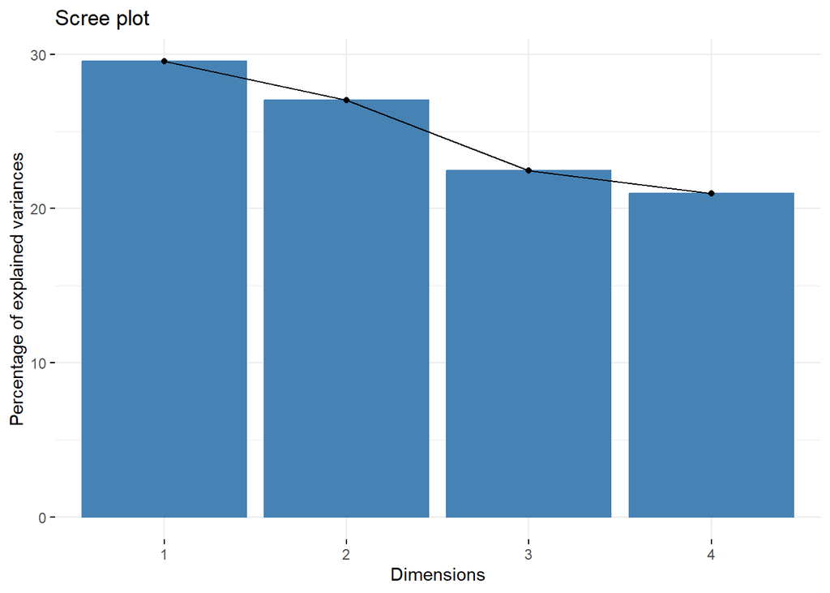

```r
fviz_screeplot(res.MCA)
```

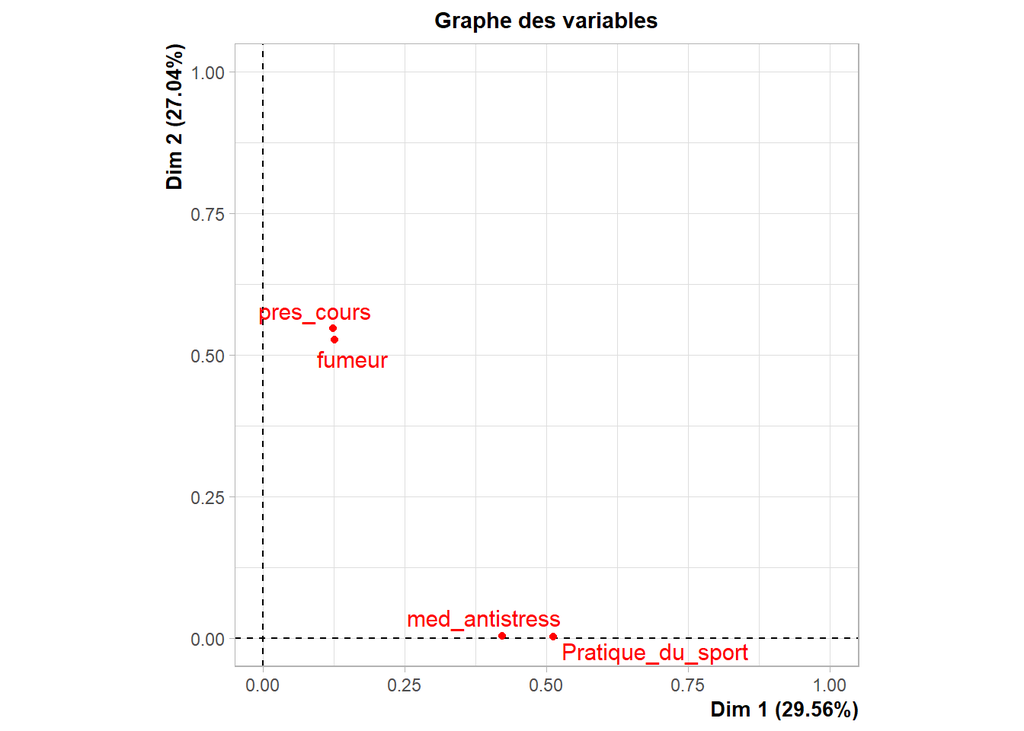

```r
plot.MCA(res.MCA, choix='var',title="Graphe des variables")
```

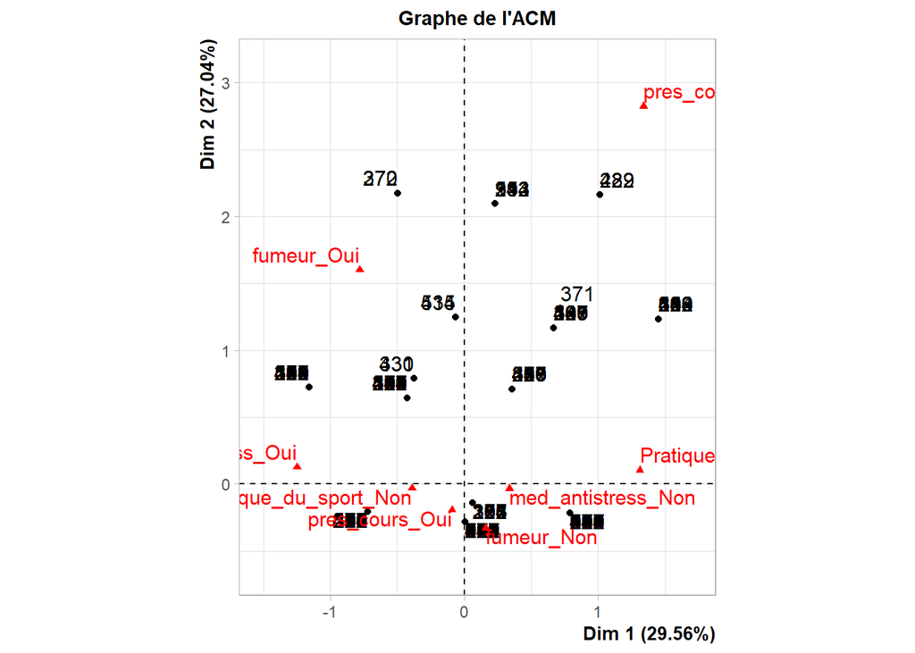

```r
plot.MCA(res.MCA,title="Graphe de l'ACM",label =c('ind','var'))
```

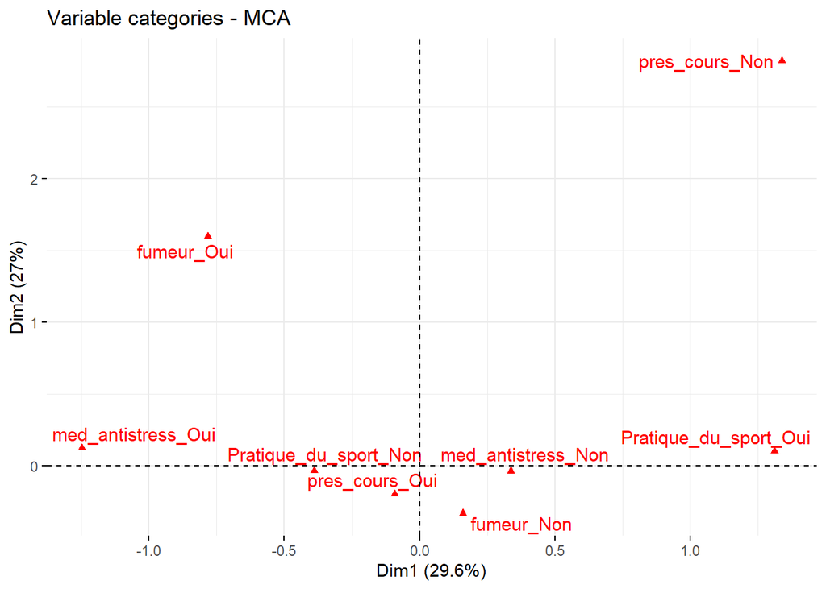

```r
#Représentation de la première carte des modalités
fviz_mca_var (res.MCA,
              repel = TRUE,
              ggtheme = theme_minimal ())
```

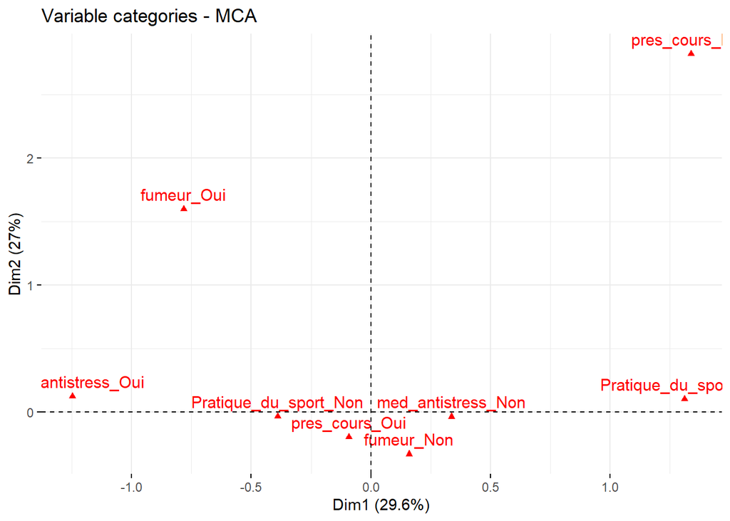

```r
# Sélectionner et visualiser les modalités avec cos2 >= 0.4
fviz_mca_var(res.MCA, select.var = list(cos2 = 0.3))
```

```r
dimdesc(res.MCA, axes=1:2, proba=0.05)$`Dim 1`
```

```
##
## Link between the variable and the categorical variable (1-way anova)
## =============================================
##                          R2      p.value
## Pratique_du_sport 0.5116436 1.483061e-86
## med_antistress    0.4221405 1.135740e-66
## fumeur            0.1257740 1.348997e-17
## pres_cours        0.1229683 3.255304e-17
##
## Link between variable abd the categories of the categorical variables
## ================================================================
##                                           Estimate      p.value
## Pratique_du_sport=Pratique_du_sport_Oui  0.4625365 1.483061e-86
## med_antistress=med_antistress_Non        0.4315318 1.135740e-66
## fumeur=fumeur_Non                        0.2562871 1.348997e-17
## pres_cours=pres_cours_Non                0.3888833 3.255304e-17
## pres_cours=pres_cours_Oui               -0.3888833 3.255304e-17
## fumeur=fumeur_Oui                       -0.2562871 1.348997e-17
## med_antistress=med_antistress_Oui       -0.4315318 1.135740e-66
## Pratique_du_sport=Pratique_du_sport_Non -0.4625365 1.483061e-86
```